# CTU19 split and sampling

Tue May 11 13:06:32 2021

```r
library(readr)
library(dplyr)
library(stringr)
library(purrr)
library(ggplot2)
library(skimr)
```

## All the analysis is done for sequence length = 1000

```r
seq_maxlen=1000
```

## Helper Functions

### Efron’s similarity function

```r
library(randomForest)
library(tidyr)
library(dplyr)
efron_simil<-function(train,prec_len){
  train<-train %>% select(1:prec_len)
  predictor_order<-sample(1:prec_len,prec_len)
  train_permuted<-train[,predictor_order]
  names(train_permuted)<-names(train)
  train_permuted$dataset<- "random"
  train$dataset<- "original"
  train<-rbind(train_permuted,train)
  train_model<-randomForest::randomForest(x=train[,1:prec_len],
  y=as.factor(train$dataset))
}
```

### PCA 2D Visualization function

```r
source("../../deepseq/config.R") # required for using deepseq #remove opt$dataset from config to use
source("../../deepseq/preprocess.R") # required for padding function
# ctu19_filtered_first4removed.csv was generated in other notebook ctu19-analysis.rmd
ctu19_first4removed<-read_csv("../datasets/ctu19_filtered_first4removed.csv")

tokenize <- function(data){
  sequencel<-sapply(data,function(x)  strsplit(x,split=""))
  x_data <- lapply(sequencel,function(x) sapply(x,function(x) tokens[[x]]))
  }

create_padded_seq<-function(data,maxlen=seq_maxlen){
tokenized_seq <- tokenize(data$State)
padded_seq<-pad_sequences_fast(unname(tokenized_seq),maxlen=maxlen,padding='post', truncating='post')
padded_seq<-data.frame(seq=padded_seq,label=data$LabelName,source=data$source, id=data$id)
}


create_pca<-function(data,maxlen=seq_maxlen)
{
pca<-prcomp(data[,1:maxlen],center=TRUE,scale.=TRUE)
  summary(pca)
  pca_data<-data.frame(pca$x,label=data$label,source=data$source, id=data$id)
  pca_plot<-ggplot(pca_data,aes(x=PC1,y=PC2))+
    geom_point(aes(color=label),alpha=0.5,size=0.1)+
    ylim(c(-40,40))+
    xlim(c(-80,80))+
    ggdark::dark_theme_bw()
pca_plot
}
```

## PCA 2D of CTU19

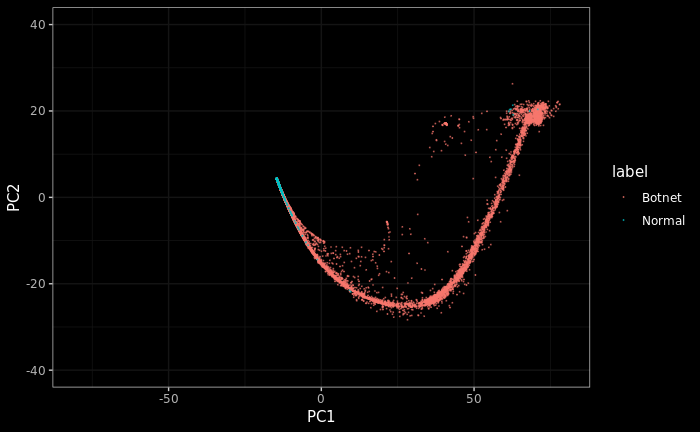

```r
padded_seq<-create_padded_seq(ctu19_first4removed,maxlen=seq_maxlen)
pca_plot<-create_pca(padded_seq,maxlen=seq_maxlen)
pca_plot
```

```r
#create_pca(padded_seq %>% filter(source=="2017-05-02_kali-normal.pcap.tsv"))
#create_pca(padded_seq %>% filter(source=="2014-01-31_capture-win7.pcap.tsv"))
#create_pca(padded_seq %>% filter(source=="2014-03-12_capture-win3.pcap.tsv"))
#create_pca(padded_seq %>% filter(source=="2013-11-25_capture-win7-2.pcap.tsv"))
#create_pca(padded_seq %>% filter(source=="2015-03-24_capture1-only-dns.pcap.tsv"))
```

## PCA 2D of CTU19 and the 19 data sources.

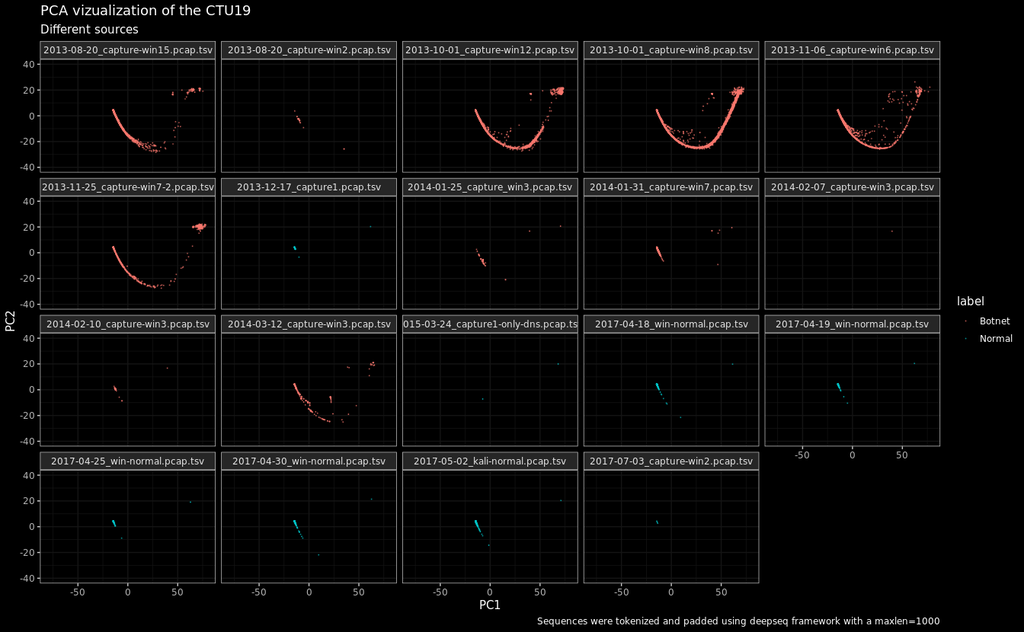

```r
pca_plot + facet_wrap(~source) + labs(title="PCA vizualization of the CTU19", subtitle="Different sources", caption="Sequences were tokenized and padded using deepseq framework with a maxlen=1000")
```

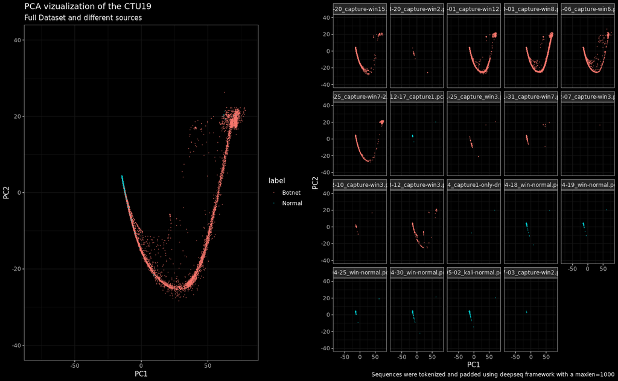

```r
gridExtra::grid.arrange(pca_plot  + labs(title="PCA vizualization of the CTU19", subtitle="Full Dataset and different sources"),
                        pca_plot + theme(legend.position = "none") + facet_wrap(~source) +labs(caption="Sequences were tokenized and padded using deepseq framework with a maxlen=1000"),ncol=2)
```

## Analysis of CTU19 for building CTU19A(train) and CTU19B(test)

A subset of CTU19 data sources is removed for building a test set. The resulting CTU19A and CTU19B. Datasets with less than 3/4 sequences are also removed.

```r
CTU19B_datasets<-c( #"2017-05-02_kali-normal.pcap.tsv",
                    "2014-01-31_capture-win7.pcap.tsv",
                    "2014-01-25_capture_win3.pcap.tsv",
                    "2013-08-20_capture-win2.pcap.tsv",
                   "2017-04-25_win-normal.pcap.tsv",
                   "2014-02-10_capture-win3.pcap.tsv",
                   "2013-11-25_capture-win7-2.pcap.tsv",
                   "2013-12-17_capture1.pcap.tsv"
                )
# Removed because number of sequences  <3
CTU19_removed<-c('2014-02-07_capture-win3.pcap.tsv',
'2015-03-24_capture1-only-dns.pcap.tsv',
'2017-07-03_capture-win2.pcap.tsv')
CTU19A_seq<-padded_seq %>% filter( ! source %in%  CTU19B_datasets )
CTU19A_seq<-CTU19A_seq %>% filter( ! source %in%  CTU19_removed )
CTU19B_seq<-padded_seq %>% filter(  source %in%  CTU19B_datasets )
CTU19A_seq$set<-"CTU19A"
CTU19B_seq$set<-"CTU19B"
```

### Checking whether CTU19A and CTU19B include the correct number of datasets

```r
CTU19A_seq %>% group_by(source) %>% summarize(n=n())
```

| source | n |
| --- | --- |
| 2013-08-20_capture-win15.pcap.tsv | 9844 |
| 2013-10-01_capture-win12.pcap.tsv | 2197 |
| 2013-10-01_capture-win8.pcap.tsv | 3463 |
| 2013-11-06_capture-win6.pcap.tsv | 2088 |
| 2014-03-12_capture-win3.pcap.tsv | 234 |
| 2017-04-18_win-normal.pcap.tsv | 387 |
| 2017-04-19_win-normal.pcap.tsv | 152 |
| 2017-04-30_win-normal.pcap.tsv | 348 |
| 2017-05-02_kali-normal.pcap.tsv | 562 |

```r
CTU19B_seq %>% group_by(source) %>% summarize(n=n())
```

| source | n |
| --- | --- |
| 2013-08-20_capture-win2.pcap.tsv | 28 |
| 2013-11-25_capture-win7-2.pcap.tsv | 627 |
| 2013-12-17_capture1.pcap.tsv | 32 |
| 2014-01-25_capture_win3.pcap.tsv | 52 |
| 2014-01-31_capture-win7.pcap.tsv | 581 |
| 2014-02-10_capture-win3.pcap.tsv | 47 |
| 2017-04-25_win-normal.pcap.tsv | 105 |

### The new CTU19A and CTU19B are visualizad using PCA.

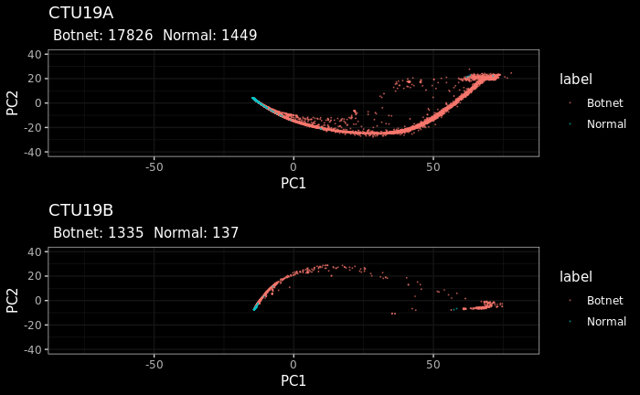

```r
CTU19A_nrow<-CTU19A_seq %>% nrow()
gridExtra::grid.arrange(create_pca(CTU19A_seq)+
                          labs(title="CTU19A",subtitle=paste(
                                                             " Botnet:",
                                                             CTU19A_seq %>% filter(label =="Botnet") %>% nrow,
                                                             " Normal:",
                                                             CTU19A_seq %>% filter(label !="Botnet") %>% nrow )
                               ),
                          create_pca(CTU19B_seq)+
                          labs(title="CTU19B",subtitle=paste(
                                                             " Botnet:",
                                                             CTU19B_seq %>% filter(label =="Botnet") %>% nrow,
                                                             " Normal:",
                                                             CTU19B_seq %>% filter(label !="Botnet") %>% nrow )


                            )
                          )
```

### Create Train/test (CTU19) csv files

```r
CTU19A_seq %>% group_by(label) %>% summarize(n=n())
```

| label | n |
| --- | --- |
| Botnet | 17826 |
| Normal | 1449 |

```r
CTU19A_csv <- inner_join(ctu19_first4removed,CTU19A_seq %>% select(id), by="id")
CTU19B_csv <- inner_join(ctu19_first4removed,CTU19B_seq %>% select(id), by="id")
readr::write_csv(CTU19A_csv,path="../datasets/samples/CTU19A-first4-removed.csv")
readr::write_csv(CTU19B_csv,path="../datasets/samples/CTU19B-first4-removed.csv")
CTU19A_csv %>% group_by(source) %>% summarize(n=n())
```

| source | n |
| --- | --- |
| 2013-08-20_capture-win15.pcap.tsv | 9844 |
| 2013-10-01_capture-win12.pcap.tsv | 2197 |
| 2013-10-01_capture-win8.pcap.tsv | 3463 |
| 2013-11-06_capture-win6.pcap.tsv | 2088 |
| 2014-03-12_capture-win3.pcap.tsv | 234 |
| 2017-04-18_win-normal.pcap.tsv | 387 |
| 2017-04-19_win-normal.pcap.tsv | 152 |
| 2017-04-30_win-normal.pcap.tsv | 348 |
| 2017-05-02_kali-normal.pcap.tsv | 562 |

```r
CTU19B_csv %>% group_by(source) %>% summarize(n=n())
```

| source | n |
| --- | --- |
| 2013-08-20_capture-win2.pcap.tsv | 28 |
| 2013-11-25_capture-win7-2.pcap.tsv | 627 |
| 2013-12-17_capture1.pcap.tsv | 32 |
| 2014-01-25_capture_win3.pcap.tsv | 52 |
| 2014-01-31_capture-win7.pcap.tsv | 581 |
| 2014-02-10_capture-win3.pcap.tsv | 47 |
| 2017-04-25_win-normal.pcap.tsv | 105 |

## Select Sample Size

We apply Efron’s algorithm for selecting different sample proportions and then classify the remaining CTU19 as `original` or `random`. Ideally the 100% of the remaining CTU19 should be considered as `original`.

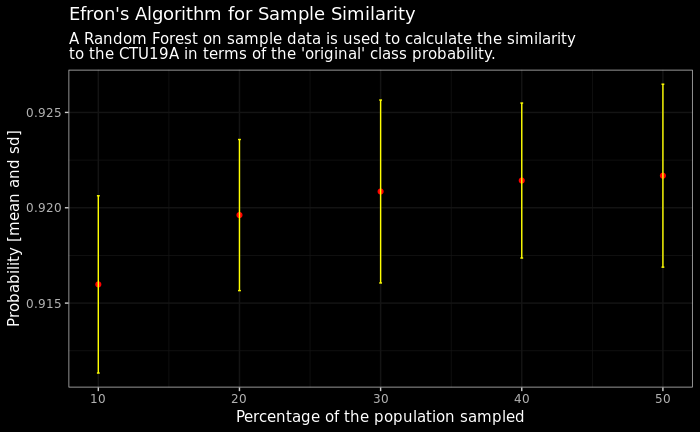

### PCA 2D visualization for comparing CTU19 and a 20% sample.

```r
 CTU19A_split<-rsample::initial_split(CTU19A_seq,prop =0.2, strata=NULL)
    CTU19A_seq_sample<-training(CTU19A_split)
    CTU19A_seq_sample_test<-testing(CTU19A_split)
    gridExtra::grid.arrange(create_pca(CTU19A_seq_sample)+labs(title="20% Sample")
                            ,create_pca(CTU19A_seq)+labs(title="CTU19A Population"))
```

[output not shown]

```r
CTU19A_seq_sample %>% group_by(source) %>% summarise(n=n())
```

| source | n |
| --- | --- |
| 2013-08-20_capture-win15.pcap.tsv | 1918 |
| 2013-10-01_capture-win12.pcap.tsv | 449 |
| 2013-10-01_capture-win8.pcap.tsv | 680 |
| 2013-11-06_capture-win6.pcap.tsv | 443 |
| 2014-03-12_capture-win3.pcap.tsv | 57 |
| 2017-04-18_win-normal.pcap.tsv | 70 |
| 2017-04-19_win-normal.pcap.tsv | 43 |
| 2017-04-30_win-normal.pcap.tsv | 78 |
| 2017-05-02_kali-normal.pcap.tsv | 117 |

```r
CTU19A_seq %>% group_by(source) %>% summarise(n=n()) %>% arrange(n)
```

| source | n |
| --- | --- |
| 2017-04-19_win-normal.pcap.tsv | 152 |
| 2014-03-12_capture-win3.pcap.tsv | 234 |
| 2017-04-30_win-normal.pcap.tsv | 348 |
| 2017-04-18_win-normal.pcap.tsv | 387 |
| 2017-05-02_kali-normal.pcap.tsv | 562 |
| 2013-11-06_capture-win6.pcap.tsv | 2088 |
| 2013-10-01_capture-win12.pcap.tsv | 2197 |
| 2013-10-01_capture-win8.pcap.tsv | 3463 |
| 2013-08-20_capture-win15.pcap.tsv | 9844 |

## Create 30 samples using pseudo Monte Carlo CV

Shuffle the dataset and pick ~4000 for training and ~1000 for test. Repeat 30 times.

```r
workdir="/home/gab/dga-wb-r/datasets/samples/"
resample_mc_cv<-function(x){
  train_ind <- sample(seq_len(nrow(x)), size = nrow(x))
  #train<-x[train_ind[1:2000],]
  #test<-x[train_ind[2001:3000],]
  train<-x[train_ind[1:4000],]
  test<-x[train_ind[4001:5000],]
  return (list(train=train,test=test))
}
for (iter in seq(30)){
    resample_mc_cv_datasets<-resample_mc_cv(CTU19A_csv)
    readr::write_csv(resample_mc_cv_datasets$train,path=paste0(workdir,"sample20-CTU19A-mc-train-",iter,".csv"))
    readr::write_csv(resample_mc_cv_datasets$test,path=paste0(workdir,"sample20-CTU19A-mc-test-",iter,".csv"))
}

CTU19A_sample<-readr::read_csv("../datasets/samples/sample20-CTU19A-mc-train-6.csv")
CTU19A_sample_padded_seq<-create_padded_seq(CTU19A_sample,maxlen=seq_maxlen)
pca_plot_CTU19A_sample_padded_seq<-create_pca(CTU19A_sample_padded_seq,maxlen=seq_maxlen)

CTU19A_sample %>% group_by(source) %>% summarise(n=n())
CTU19A_sample %>% group_by(LabelName) %>% summarise(n=n())
pca_plot_CTU19A_sample_padded_seq+labs(title="PCA of a training sample with 20% of the CTU19A")
```

[output not shown]

### Checking if all train samples include the 9 sources from CTU19A

```r
samples_files %>% group_by(source,sample) %>% summarise(n=n()) %>% group_by(sample) %>% summarise(sources=n())
```

| sample | sources |
| --- | --- |
| 1 | 9 |
| 2 | 9 |
| 3 | 9 |
| 4 | 9 |
| 5 | 9 |
| 6 | 9 |
| 7 | 9 |
| 8 | 9 |
| 9 | 9 |
| 10 | 9 |

[output cut: 20 more lines]

### Checking if all test samples include the 9 sources from CTU19A

```r
samples_files %>% group_by(source,sample) %>% summarise(n=n()) %>% group_by(sample) %>% summarise(sources=n())
```

| sample | sources |
| --- | --- |
| 1 | 9 |
| 2 | 9 |
| 3 | 9 |
| 4 | 9 |
| 5 | 9 |
| 6 | 9 |
| 7 | 9 |
| 8 | 9 |
| 9 | 9 |
| 10 | 9 |

[output cut: 20 more lines]

### Resulting datasets and samples

The final version of CTU19A and CTU19B as well as the 10% and 20% samples are located [here](https://www.dropbox.com/sh/ijiepa3l8zxy8lu/AABPDFjo9eMNPra_3SfPZyeNa?dl=0)

# Augmentation

## Helper functions

### Shifter

```r
shifter <- function(x, n = 1) {
  if (n == 0) x else c(tail(x, -n), head(x, n))
}
augment_dataset <- function(dataset, n) {
  aug_dataset <- dataset[1,] # use first row for adding
  for (i in 1:n) {
  j <- sample(1:nrow(dataset), 1)
  k <- sample(1:nchar(dataset$State[j]), 1)
  aug_example <- dataset[j, ]
  aug_example$State <- aug_example$State %>%
  strsplit(split = "") %>%
  unlist() %>%
  shifter(n = k) %>%
  paste(collapse = '')
  aug_example$source <-
  paste(aug_example$source, "_augmented", sep = "")
  aug_example$id <- aug_example$id + 1e6
 # aug_dataset <- rbind(aug_dataset, aug_example)
  aug_dataset <- aug_dataset %>% tibble::add_row(aug_example)
  }
  aug_dataset[-1,] # remove first row
}
```

### Generating augmented examples

```r
workdir="/home/gab/dga-wb-r/datasets/samples/"
for (iter in seq(30)){
    train_ex<-readr::read_csv(paste0(workdir,"sample20-CTU19A-mc-train-",iter,".csv"))
    train_ex_normal <-train_ex %>% filter(LabelName == "Normal")
    train_ex_normal_aug<-augment_dataset(train_ex_normal,
                                         (train_ex %>% nrow*2 - train_ex_normal %>% nrow))
    train_ex <- rbind(train_ex,train_ex_normal_aug)

    train_ex_botnet <-train_ex %>% filter(LabelName == "Botnet")
    train_ex_normal <-train_ex %>% filter(LabelName == "Normal")
    train_ex_botnet_aug<-augment_dataset(train_ex_botnet,
                                         (train_ex_normal %>% nrow - train_ex_botnet %>% nrow))

    train_ex <- rbind(train_ex,train_ex_botnet_aug)

    readr::write_csv(train_ex,path=paste0(workdir,"sample20-CTU19A-mc-train-augmentedx2-",iter,".csv"))

}
CTU19A_sample_augmented<-readr::read_csv("../datasets/samples/sample20-CTU19A-mc-train-augmentedx2-2.csv")
CTU19A_sample_augmented %>% group_by(source) %>% summarise(n=n())
```

| source | n |
| --- | --- |
| 2013-08-20_capture-win15.pcap.tsv | 2025 |
| 2013-08-20_capture-win15.pcap.tsv_augmented | 2327 |
| 2013-10-01_capture-win12.pcap.tsv | 451 |
| 2013-10-01_capture-win12.pcap.tsv_augmented | 559 |
| 2013-10-01_capture-win8.pcap.tsv | 724 |
| 2013-10-01_capture-win8.pcap.tsv_augmented | 850 |
| 2013-11-06_capture-win6.pcap.tsv | 435 |
| 2013-11-06_capture-win6.pcap.tsv_augmented | 514 |
| 2014-03-12_capture-win3.pcap.tsv | 48 |
| 2014-03-12_capture-win3.pcap.tsv_augmented | 67 |

[output cut: 8 more lines]

```r
CTU19A_sample_augmented %>% group_by(LabelName) %>% summarise(n=n())
```

| LabelName | n |
| --- | --- |
| Botnet | 8000 |
| Normal | 8000 |